# IODS course project

Before modeling the data, we need to check for and remove outliers.

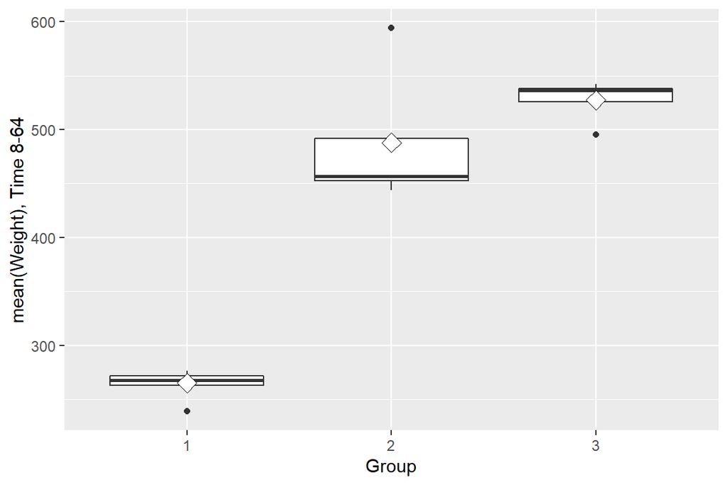

```r
# Create a summary data by Group and ID with mean as the summary variable (ignoring baseline Time 1).
RATSL8S <- RATSL %>%
  filter(Time > 1) %>%
  group_by(Group, ID) %>%
  summarise( mean=mean(Weight) ) %>%
  ungroup()


# Draw a boxplot of the mean versus treatment
ggplot(RATSL8S, aes(x = Group, y = mean)) +
  geom_boxplot() +
  stat_summary(fun.y = "mean", geom = "point", shape=23, size=4, fill = "white") +
  scale_y_continuous(name = "mean(Weight), Time 8-64")
```

In diet group 2, there is one outlier (RATSL8S ~ 600). We remove this observation.

```r
RATSL8S1 <- RATSL8S %>%
  filter(mean < 570)
```

Finally, we apply a t-test to assess any difference between the treatment groups, and also calculate a confidence interval for this difference.

```r
# Perform a two-sample t-test and observe the differences as seen in in the boxplots of the previous exercise

# Between group 1 and 2
RATSL8S1_12 <- RATSL8S1%>%
  filter(Group == "1"  | Group == "2" )

t.test(mean ~ Group, data = RATSL8S1_12, var.equal = TRUE)
```

```
##
##  Two Sample t-test
##
## data:  mean by Group
## t = -25.399, df = 9, p-value = 1.094e-09
## alternative hypothesis: true difference in means is not equal to 0
## 95 percent confidence interval:
##  -204.0633 -170.6867
## sample estimates:
## mean in group 1 mean in group 2
##         265.025         452.400
```

```r
# Between group 2 and 3
RATSL8S1_23 <- RATSL8S1%>%
  filter(Group == "2"  | Group == "3" )

t.test(mean ~ Group, data = RATSL8S1_23, var.equal = TRUE)
```

```
##
##  Two Sample t-test
##
## data:  mean by Group
## t = -5.632, df = 5, p-value = 0.002446
## alternative hypothesis: true difference in means is not equal to 0
## 95 percent confidence interval:
##  -109.37769  -40.82231
## sample estimates:
## mean in group 2 mean in group 3
##           452.4           527.5
```

Fit a linear model that conditions on the baseline value.

```r
# Add the baseline from the original data as a new variable to the summary data
RATSL8S2 <- RATSL8S %>%
  mutate(baseline = RATS$WD1)

# Fit the linear model with mean as the target and baseline + Group as the response from the RATSL8S1
fit <- lm(mean ~ baseline + Group, data = RATSL8S2)

# Compute the analysis of variance table for the fitted model with anova()
anova(fit)
```

```
## Analysis of Variance Table
##
## Response: mean
##           Df Sum Sq Mean Sq   F value   Pr(>F)
## baseline   1 253625  253625 1859.8201 1.57e-14 ***
## Group      2    879     439    3.2219  0.07586 .
## Residuals 12   1636     136
## ---
## Signif. codes:  0 '***' 0.001 '**' 0.01 '*' 0.05 '.' 0.1 ' ' 1
```

Baseline Weight is strongly related to Weight taken after treatment has begun (p-value: 1.57e-14), but there is small evidence (p-value: 0.07586) of a diet difference even after conditioning on the baseline value.

Remember: The summary measure approach provides a useful first step in making inferences about the data, but a more complete and a more appropriate analysis will involve fitting a suitable model to the data and estimating parameters that link the explanatory variables of interest to the repeated measures of the response variable.

**Analysing the BPRS data set**

“40 male subjects were randomly assigned to one of two treatment groups and each subject was rated on the brief psychiatric rating scale (BPRS) measured before treatment began (week 0) and then at weekly intervals for eight weeks. The BPRS assesses the level of 18 symptom constructs such as hostility, suspiciousness, hallucinations and grandiosity; each of these is rated from one (not present) to seven (extremely severe).” https://mooc.helsinki.fi/pluginfile.php/78192/course/section/3817/MABS4IODS.pdf

```r
# Load the data set (wide form)
BPRS <- read.csv("Z:\\IODS\\IODS\\data\\BPRS.csv")

# Look at the data set BPRS
BPRS
```

```
##    treatment subject week0 week1 week2 week3 week4 week5 week6 week7 week8
## 1          1       1    42    36    36    43    41    40    38    47    51
## 2          1       2    58    68    61    55    43    34    28    28    28
## 3          1       3    54    55    41    38    43    28    29    25    24
## 4          1       4    55    77    49    54    56    50    47    42    46
## 5          1       5    72    75    72    65    50    39    32    38    32
## 6          1       6    48    43    41    38    36    29    33    27    25
## 7          1       7    71    61    47    30    27    40    30    31    31
## 8          1       8    30    36    38    38    31    26    26    25    24
## 9          1       9    41    43    39    35    28    22    20    23    21
## 10         1      10    57    51    51    55    53    43    43    39    32
## 11         1      11    30    34    34    41    36    36    38    36    36
## 12         1      12    55    52    49    54    48    43    37    36    31
## 13         1      13    36    32    36    31    25    25    21    19    22
## 14         1      14    38    35    36    34    25    27    25    26    26
```

[output cut: 26 more lines]

```r
# Load the data set (long form)
BPRSL <- read.csv("Z:\\IODS\\IODS\\data\\BPRSL.csv")

# Factor treatment & subject
BPRSL$treatment <- factor(BPRSL$treatment)
BPRSL$subject <- factor(BPRSL$subject)

# Look at the structure of the data set BPRSL
str(BPRSL)
```

```
## 'data.frame':    360 obs. of  5 variables:
##  $ treatment: Factor w/ 2 levels "1","2": 1 1 1 1 1 1 1 1 1 1 ...
##  $ subject  : Factor w/ 20 levels "1","2","3","4",..: 1 2 3 4 5 6 7 8 9 10 ...
##  $ weeks    : Factor w/ 9 levels "week0","week1",..: 1 1 1 1 1 1 1 1 1 1 ...
##  $ bprs     : int  42 58 54 55 72 48 71 30 41 57 ...
##  $ week     : int  0 0 0 0 0 0 0 0 0 0 ...
```

Note: the number of observations (bprs) is the same in both forms. In the long form, all measurement points are represented by only own variable, whereas in the wide from, all measurement points have their own variable.

To begin, we will plot the data, identifying the observations in each group but ignoring the longitudinal nature of the data.

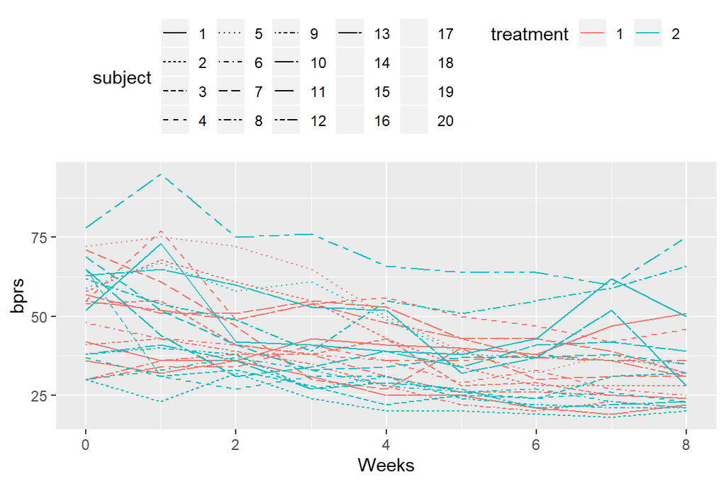

```r
ggplot(BPRSL, aes(x = week, y = bprs, linetype = subject)) +
  geom_line(aes(color = treatment)) + scale_x_continuous(name = "Weeks") + scale_y_continuous(name = "bprs") + theme(legend.position = "top")
```

The BPRS score seems to be decreasing in both treatment groups, but it does not seem to be a difference between the groups.

Next, we will fit a multiple linear regression model with bprs as response and week and treatment as explanatory variables. Note that we still ignore the repeated-measures structure of the data.

```r
# create a regression model RATS_reg
BPRS_reg <- lm(bprs ~ week + treatment, data=BPRSL)

# print out a summary of the model
summary(BPRS_reg)
```

```
##
## Call:
## lm(formula = bprs ~ week + treatment, data = BPRSL)
##
## Residuals:
##     Min      1Q  Median      3Q     Max
## -22.454  -8.965  -3.196   7.002  50.244
##
## Coefficients:
##             Estimate Std. Error t value Pr(>|t|)
## (Intercept)  46.4539     1.3670  33.982   <2e-16 ***
## week         -2.2704     0.2524  -8.995   <2e-16 ***
## treatment2    0.5722     1.3034   0.439    0.661
## ---
## Signif. codes:  0 '***' 0.001 '**' 0.01 '*' 0.05 '.' 0.1 ' ' 1
##
## Residual standard error: 12.37 on 357 degrees of freedom
## Multiple R-squared:  0.1851, Adjusted R-squared:  0.1806
## F-statistic: 40.55 on 2 and 357 DF,  p-value: < 2.2e-16
```

Week is significant, meaning that the bprs decreaes with time for both groups. However, there seems to be no significant difference between the groups.

The previous model assumes independence of the repeated measures of bprs, and this assumption is highly unlikely. So, now we will move on to consider both some more appropriate graphics and appropriate models.

We will first fit the random intercept model for the same two explanatory variables: week and treatment. Fitting a random intercept model allows the linear regression fit for each subject to differ in intercept from other subjects.

```r
# access library lme4
library(lme4)
# Fit the random intercept model with the rat ID as the random effect
BPRS_ref <- lmer(bprs ~ week + treatment + (1 | subject), data = BPRSL, REML = FALSE)

# Print the summary of the model
summary(BPRS_ref)
```

```
## Linear mixed model fit by maximum likelihood  ['lmerMod']
## Formula: bprs ~ week + treatment + (1 | subject)
##    Data: BPRSL
##
##      AIC      BIC   logLik deviance df.resid
##   2748.7   2768.1  -1369.4   2738.7      355
##
## Scaled residuals:
##     Min      1Q  Median      3Q     Max
## -3.0481 -0.6749 -0.1361  0.4813  3.4855
##
## Random effects:
##  Groups   Name        Variance Std.Dev.
##  subject  (Intercept)  47.41    6.885
##  Residual             104.21   10.208
## Number of obs: 360, groups:  subject, 20
##
## Fixed effects:
##             Estimate Std. Error t value
## (Intercept)  46.4539     1.9090  24.334
## week         -2.2704     0.2084 -10.896
## treatment2    0.5722     1.0761   0.532
##
## Correlation of Fixed Effects:
##            (Intr) week
## week       -0.437
## treatment2 -0.282  0.000
```

Now we can move on to fit the random intercept and random slope model to the bprs data. Fitting a random intercept and random slope model allows the linear regression fits for each individual to differ in intercept but also in slope. This way it is possible to account for the individual differences in the bprs profiles, but also the effect of time.

```r
# Fit the random intercept and slope model with week and subject as the random effects
BPRS_ref1 <- lmer(bprs ~ week + treatment + (week | subject), data = BPRSL, REML = FALSE)

# print a summary of the model
summary(BPRS_ref1)
```

```
## Linear mixed model fit by maximum likelihood  ['lmerMod']
## Formula: bprs ~ week + treatment + (week | subject)
##    Data: BPRSL
##
##      AIC      BIC   logLik deviance df.resid
##   2745.4   2772.6  -1365.7   2731.4      353
##
## Scaled residuals:
##     Min      1Q  Median      3Q     Max
## -2.8919 -0.6194 -0.0691  0.5531  3.7977
##
## Random effects:
##  Groups   Name        Variance Std.Dev. Corr
##  subject  (Intercept) 64.8222  8.0512
##           week         0.9609  0.9803   -0.51
##  Residual             97.4304  9.8707
## Number of obs: 360, groups:  subject, 20
##
## Fixed effects:
##             Estimate Std. Error t value
## (Intercept)  46.4539     2.1052  22.066
## week         -2.2704     0.2977  -7.626
## treatment2    0.5722     1.0405   0.550
##
## Correlation of Fixed Effects:
##            (Intr) week
## week       -0.582
## treatment2 -0.247  0.000
```

```r
# Compute the analysis of variance tables of the models RATS_ref and RATS_ref1
anova(BPRS_ref1, BPRS_ref)
```

```
## Data: BPRSL
## Models:
## BPRS_ref: bprs ~ week + treatment + (1 | subject)
## BPRS_ref1: bprs ~ week + treatment + (week | subject)
##           Df    AIC    BIC  logLik deviance  Chisq Chi Df Pr(>Chisq)
## BPRS_ref   5 2748.7 2768.1 -1369.4   2738.7
## BPRS_ref1  7 2745.4 2772.6 -1365.7   2731.4 7.2721      2    0.02636 *
## ---
## Signif. codes:  0 '***' 0.001 '**' 0.01 '*' 0.05 '.' 0.1 ' ' 1
```

The small p-value indicate better fit against the comparison model.

Finally, we can fit a random intercept and slope model that allows for a treatment × week interaction.

```r
# create a random intercept and random slope model with the interaction
BPRS_ref2 <- lmer(bprs ~ week + treatment + week*treatment + (week | subject), data = BPRSL, REML = FALSE)

# print a summary of the model
summary(BPRS_ref2)
```

```
## Linear mixed model fit by maximum likelihood  ['lmerMod']
## Formula: bprs ~ week + treatment + week * treatment + (week | subject)
##    Data: BPRSL
##
##      AIC      BIC   logLik deviance df.resid
##   2744.3   2775.4  -1364.1   2728.3      352
##
## Scaled residuals:
##     Min      1Q  Median      3Q     Max
## -3.0512 -0.6271 -0.0768  0.5288  3.9260
##
## Random effects:
##  Groups   Name        Variance Std.Dev. Corr
##  subject  (Intercept) 64.9964  8.0620
##           week         0.9687  0.9842   -0.51
##  Residual             96.4707  9.8220
## Number of obs: 360, groups:  subject, 20
##
## Fixed effects:
##                 Estimate Std. Error t value
## (Intercept)      47.8856     2.2521  21.262
## week             -2.6283     0.3589  -7.323
## treatment2       -2.2911     1.9090  -1.200
## week:treatment2   0.7158     0.4010   1.785
##
## Correlation of Fixed Effects:
##             (Intr) week   trtmn2
## week        -0.650
## treatment2  -0.424  0.469
## wek:trtmnt2  0.356 -0.559 -0.840
```

```r
# Compute the analysis of variance tables of the models RATS_ref2 and RATS_ref1
anova(BPRS_ref2, BPRS_ref1)
```

```
## Data: BPRSL
## Models:
## BPRS_ref1: bprs ~ week + treatment + (week | subject)
## BPRS_ref2: bprs ~ week + treatment + week * treatment + (week | subject)
##           Df    AIC    BIC  logLik deviance  Chisq Chi Df Pr(>Chisq)
## BPRS_ref1  7 2745.4 2772.6 -1365.7   2731.4
## BPRS_ref2  8 2744.3 2775.4 -1364.1   2728.3 3.1712      1    0.07495 .
## ---
## Signif. codes:  0 '***' 0.001 '**' 0.01 '*' 0.05 '.' 0.1 ' ' 1
```

The interaction model hardly provide any better fit for the bprs data. (P-value not “very small”)

Finally, we draw the fitted values of the model.

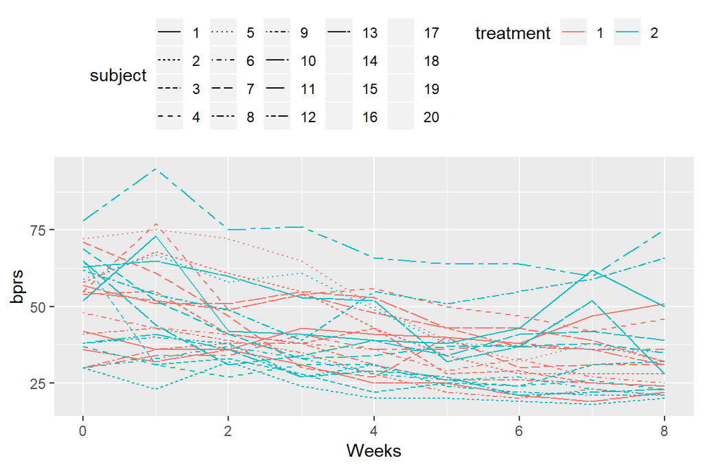

```r
ggplot(BPRSL, aes(x = week, y = bprs, linetype = subject)) +
  geom_line(aes(color = treatment)) + scale_x_continuous(name = "Weeks") + scale_y_continuous(name = "bprs") + theme(legend.position = "top")
```

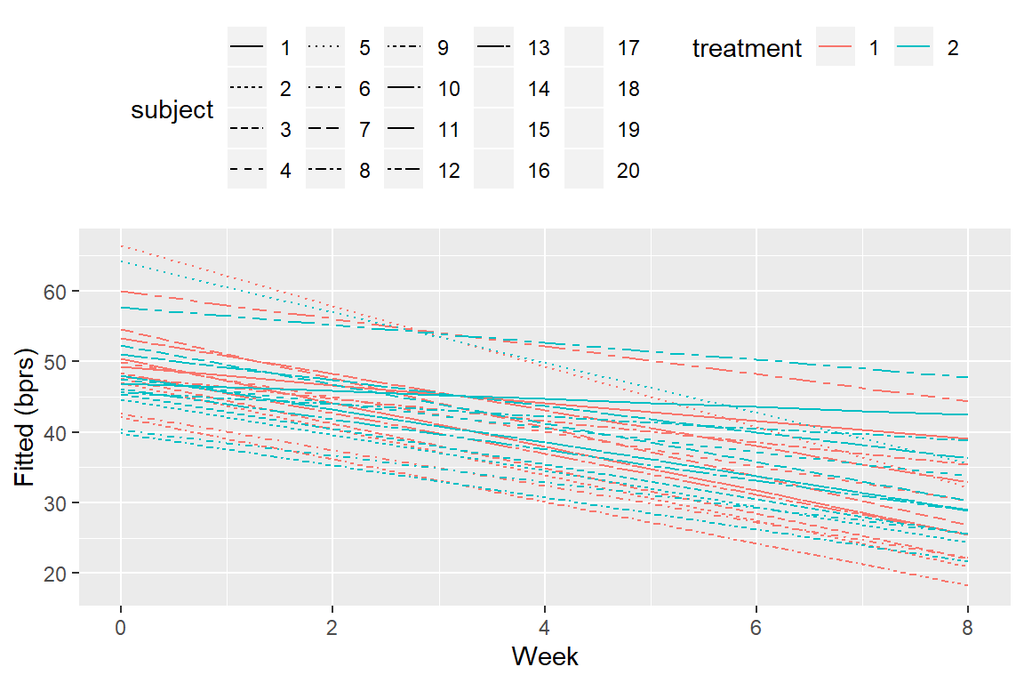

```r
# Create a vector of the fitted values of the model using the function fitted()
Fitted <- fitted(BPRS_ref2)

# Create a new column fitted to RATSL
BPRSL <- mutate(BPRSL, Fitted)

# draw the plot of BPRSL with the Fitted values of bprs
ggplot(BPRSL, aes(x = week, y = Fitted, linetype = subject)) +
  geom_line(aes(color = treatment)) +
  scale_x_continuous(name = "Week") +
  scale_y_continuous(name = "Fitted (bprs)") +
  theme(legend.position = "top")
```